# Fire-Ants-Scrum

January 10, 2019

## THE FIRE ANTS

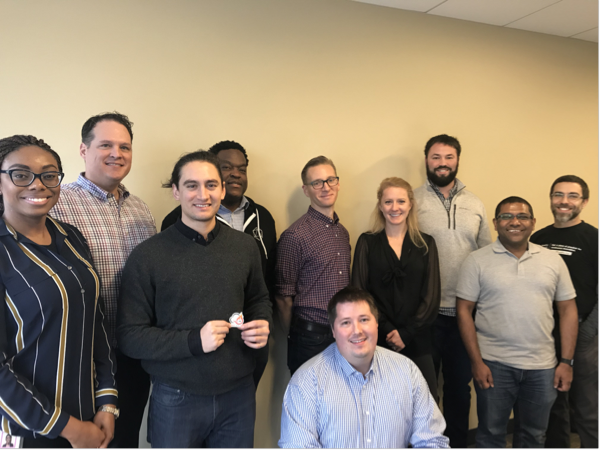

The Fire Ants

## Admin Items

- Happy 2019!
- Digital Ocean Cleanup
- Monitoring the EMC Code Team Situation.
- MDC Consolidation

[figure not shown]

## PF2.0 Items in Flight

- Finish and test **DataFreshAnt** - Good to Go.
- Scheduled **MachineLearningAnt** Pair Session (scheduling, inputs, outputs) - CG met with Cameron Stewart. Concurrently, DC attempted some changes. ML-Ant currently working.
- Finish and test **MachineLearningAnt** - Good to Go.
- Finalize **VisualizationAnt** - rebranded from **AnalyticsAnt**. DC and JB WIP
- Upload **MobileAnt** to AppleStore - no time to work on this since NOV. Nix to get with Sweers.
- Finalize **API-Ant** - AS implemented player aggregator.
- Unique MLBid List - AS & CG researching options. Edge test possible to idnetify players with correct range of AtBats.
- Updated Diagram - JB, DN, AS input needed. Original inputs found!!!!
- **DataFlow** - will run every 24 hours. Working on scheduling. KS will schedule pair programming.

## AROUND THE HORN

- Bat to clean-up Digital Ocean
- AS noticed customer developers working with Concourse. Prompted discussion with development tools. HyVee Grocery Stores
- Bat discussed USPS and his AppDev micros-services discussion regarding their Payroll